# Exploring Nobel Laureates with Python ---DS220 Project 2 Junbo Zhao

- GitHub profile:https://github.com/Nmsl985211
- Project repo:https://github.com/Nmsl985211/DS220_project2_JunboZhao
- Published site:https://nmsl985211.github.io/DS220_project2_JunboZhao/

This notebook uses the Nobel Prize laureates dataset to look for basic patterns across time, locations, prize categories, gender, and age-at-award. I load the CSV into pandas, do light cleaning, and then answer eight questions with summaries and plots.

- Data source: http://api.nobelprize.org/v1/laureate.csv

```python
import numpy as np
import pandas as pd
import matplotlib.pyplot as plt

# so that plots show up nicely inside the notebook
%matplotlib inline

# load the Nobel laureates data, I saved the file as nobel_laureates.csv in the same folder)
nobel = pd.read_csv("nobel_laureates.csv")

nobel.head()
```

|  | id | firstname | surname | born | died | bornCountry | bornCountryCode | bornCity | diedCountry | diedCountryCode | diedCity | gender | year | category | overallMotivation | share | motivation | name | city | country |
| --- | --- | --- | --- | --- | --- | --- | --- | --- | --- | --- | --- | --- | --- | --- | --- | --- | --- | --- | --- | --- |
| 0 | 1 | Wilhelm Conrad | Röntgen | 1845-03-27 | 1923-02-10 | Prussia (now Germany) | DE | Lennep (now Remscheid) | Germany | DE | Munich | male | 1901 | physics | NaN | 1 | "in recognition of the extraordinary services ... | Munich University | Munich | Germany |
| 1 | 2 | Hendrik A. | Lorentz | 1853-07-18 | 1928-02-04 | the Netherlands | NL | Arnhem | the Netherlands | NL | NaN | male | 1902 | physics | NaN | 2 | "in recognition of the extraordinary service t... | Leiden University | Leiden | the Netherlands |
| 2 | 3 | Pieter | Zeeman | 1865-05-25 | 1943-10-09 | the Netherlands | NL | Zonnemaire | the Netherlands | NL | Amsterdam | male | 1902 | physics | NaN | 2 | "in recognition of the extraordinary service t... | Amsterdam University | Amsterdam | the Netherlands |
| 3 | 4 | Henri | Becquerel | 1852-12-15 | 1908-08-25 | France | FR | Paris | France | FR | NaN | male | 1903 | physics | NaN | 2 | "in recognition of the extraordinary services ... | École Polytechnique | Paris | France |
| 4 | 5 | Pierre | Curie | 1859-05-15 | 1906-04-19 | France | FR | Paris | France | FR | Paris | male | 1903 | physics | NaN | 4 | "in recognition of the extraordinary services ... | École municipale de physique et de chimie indu... | Paris | France |

# 1. First look at the raw data

Before doing any serious analysis I want to see what the raw data looks like，  
how many rows and columns there are, and what kinds of fields we get from the API. Below I just print some basic info and simple descriptive statistics.

```python
# number of rows and columns
nobel.shape

# quick overview of the columns and data types
nobel.info()

# basic descriptive statistics for numeric columns
nobel.describe()
```

```
<class 'pandas.core.frame.DataFrame'>
RangeIndex: 1026 entries, 0 to 1025
Data columns (total 20 columns):
 #   Column             Non-Null Count  Dtype
---  ------             --------------  -----
 0   id                 1026 non-null   int64
 1   firstname          1026 non-null   object
 2   surname            993 non-null    object
 3   born               1025 non-null   object
 4   died               1026 non-null   object
 5   bornCountry        991 non-null    object
 6   bornCountryCode    991 non-null    object
 7   bornCity           987 non-null    object
 8   diedCountry        674 non-null    object
 9   diedCountryCode    674 non-null    object
 10  diedCity           668 non-null    object
 11  gender             1026 non-null   object
 12  year               1026 non-null   int64
 13  category           1026 non-null   object
 14  overallMotivation  26 non-null     object
 15  share              1026 non-null   int64
 16  motivation         1026 non-null   object
 17  name               758 non-null    object
 18  city               753 non-null    object
 19  country            755 non-null    object
dtypes: int64(3), object(17)
memory usage: 160.4+ KB
```

|  | id | year | share |
| --- | --- | --- | --- |
| count | 1026.000000 | 1026.000000 | 1026.000000 |
| mean | 522.742690 | 1975.008772 | 2.041910 |
| std | 306.260247 | 35.006716 | 0.948014 |
| min | 1.000000 | 1901.000000 | 1.000000 |
| 25% | 258.250000 | 1950.000000 | 1.000000 |
| 50% | 514.500000 | 1980.000000 | 2.000000 |
| 75% | 785.250000 | 2004.000000 | 3.000000 |
| max | 1060.000000 | 2025.000000 | 4.000000 |

# 2. Basic cleaning and preprocessing

The original CSV already has a lot of useful fields, but some of them are strings that I want to convert to more convenient types.

In particular:

1. I convert the `born` and `died` columns to proper datetime values and extract the birth year.
2. I keep the country and city of birth as they are, but I am aware that some country names may be historical.
3. I drop a few obviously empty rows where almost everything is missing.

None of this is very fancy, but I think it makes later analysis a bit easier.

```python
# convert born and died to datetime; errors="coerce" turns bad dates into NaT
nobel["born"] = pd.to_datetime(nobel["born"], errors="coerce")
nobel["died"] = pd.to_datetime(nobel["died"], errors="coerce")

# extract birth year as a separate column
nobel["born_year"] = nobel["born"].dt.year

# very rough cleaning: drop rows where even firstname and surname are missing
nobel_clean = nobel.dropna(subset=["firstname", "surname"])

nobel_clean[["firstname", "surname", "born", "born_year"]].head()
```

|  | firstname | surname | born | born_year |
| --- | --- | --- | --- | --- |
| 0 | Wilhelm Conrad | Röntgen | 1845-03-27 | 1845.0 |
| 1 | Hendrik A. | Lorentz | 1853-07-18 | 1853.0 |
| 2 | Pieter | Zeeman | 1865-05-25 | 1865.0 |
| 3 | Henri | Becquerel | 1852-12-15 | 1852.0 |
| 4 | Pierre | Curie | 1859-05-15 | 1859.0 |

```python
# Quick examples of using DataFrame.query() for filtering

female_laureates = nobel_clean.query("gender == 'female'")
after_1950 = nobel_clean.query("year >= 1950")

female_laureates.shape[0], after_1950.shape[0]
```

```
(67, 750)
```

# 3. Questions I want to explore

To keep the analysis focused, I wrote down a small list of questions that I would like to answer with this dataset:

1. Q1: How many laureates are there in total in this dataset?
2. Q2: Which birth countries have produced the most Nobel laureates?
3. Q3: What does the overall gender distribution of Nobel laureates look like?
4. Q4: How has the number of laureates changed over time by decade?
5. Q5: Which prize categories have the most laureates?
6. Q6: For the records where birth year is known, what is the typical age range when people receive the prize?
7. Q7: Are there noticeable differences in average age at the time of the award between prize categories?
8. Q8: Which birth cities appear most often among laureates?

I think these are the deep possible questions, and they are simple enough and still reveal some interesting patterns about Nobel Prize winners.

# 4. Exploring the questions one by one

## Q1: How many laureates are in this dataset?

First I just want to know how big this dataset actually is,  
so I count how many unique laureate IDs appear in the file.

```python
total_rows = nobel_clean.shape[0]
unique_ids = nobel_clean["id"].nunique()

total_rows, unique_ids
```

```
(993, 988)
```

The first number is the total number of rows in the cleaned table,  
while the second number is the number of distinct laureate IDs.  
The difference comes from the fact that some people received more than one prize,  
so they show up multiple times in the dataset.

## Q2: Which birth countries have produced the most laureates?

Here I look at the `bornCountry` column, count how many times each country appears,  
and then take the top 10. This is of course influenced by historical country names,  
but it still gives a rough idea of where Nobel winners tend to come from. python

```python
country_counts = (
    nobel_clean["bornCountry"]
    .value_counts()
    .head(10)
)

country_counts
```

```
bornCountry
USA                298
United Kingdom      95
Germany             67
France              60
Sweden              30
Japan               30
Canada              22
the Netherlands     20
Switzerland         19
Russia              18
Name: count, dtype: int64
```

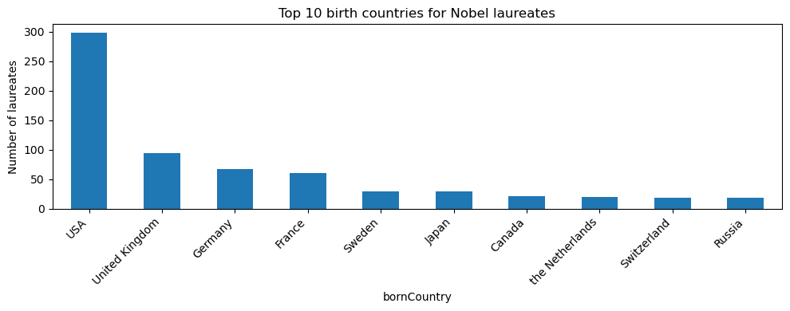

```python
plt.figure(figsize=(10, 4))
country_counts.plot(kind="bar")
plt.title("Top 10 birth countries for Nobel laureates")
plt.ylabel("Number of laureates")
plt.xticks(rotation=45, ha="right")
plt.tight_layout()
plt.show()
```

From this bar chart it is clear that a small group of countries dominates the list.  
This matches the common impression that a handful of nations with long academic traditions  
produce a large share of Nobel Prize winners.

## Q3: What is the gender distribution of Nobel laureates?

Next I check how many laureates are labeled as male, female, or unknown.  
This is one of the most obvious statistics to look at,  
and it also shows how unbalanced the prizes have been historically.

```python
gender_counts = nobel_clean["gender"].value_counts()
gender_counts
```

```
gender
male      926
female     67
Name: count, dtype: int64
```

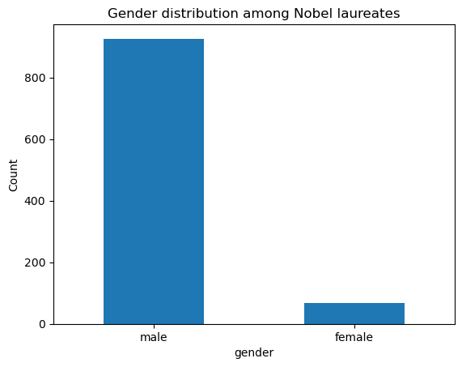

```python
gender_counts.plot(kind="bar")
plt.title("Gender distribution among Nobel laureates")
plt.ylabel("Count")
plt.xticks(rotation=0)
plt.show()
```

The result is extremely skewed: almost all laureates are recorded as male,  
with only a relatively small number of female laureates.  
This is still striking to see difference numerically.

## Q4: How has the number of laureates changed over time (by decade)?

To see the long-term trend, I group the data by decade using the `year` column.  
I ignore rows where the year is missing.

```python
# I drop missing years and build a decade column
nobel_clean = nobel_clean.dropna(subset=["year"])
nobel_clean["decade"] = (nobel_clean["year"] // 10) * 10

decade_counts = (
    nobel_clean.groupby("decade")["id"]
    .nunique()
)

decade_counts.head()
```

```
decade
1900    56
1910    38
1920    54
1930    55
1940    40
Name: id, dtype: int64
```

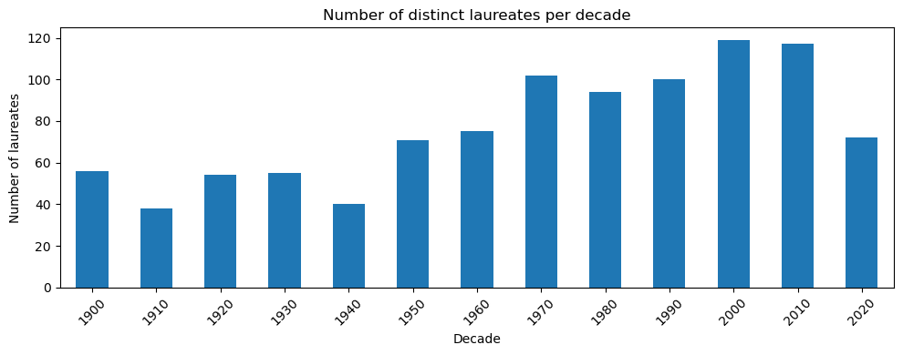

```python
decade_counts.plot(kind="bar", figsize=(10, 4))
plt.title("Number of distinct laureates per decade")
plt.ylabel("Number of laureates")
plt.xlabel("Decade")
plt.xticks(rotation=45)
plt.tight_layout()
plt.show()
```

The bar charts shows that the number of laureates per decade has generally increased over time,  
especially after the mid-20th century.  
Part of this comes from the creation of new prize categories and the growing size of the scientific community.

## Q5: Which prize categories have the most laureates?

Here I look at the `category` column and simply count the number of records per category.

```python
category_counts = nobel_clean["category"].value_counts()
category_counts
```

```
category
medicine      232
physics       230
chemistry     200
literature    122
peace         110
economics      99
Name: count, dtype: int64
```

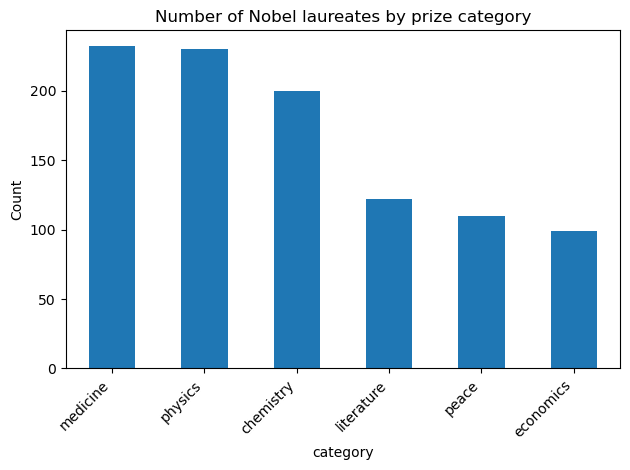

```python
category_counts.plot(kind="bar")
plt.title("Number of Nobel laureates by prize category")
plt.ylabel("Count")
plt.xticks(rotation=45, ha="right")
plt.tight_layout()
plt.show()
```

The most populated categories are usually Physics, Chemistry, and Medicine,  
but Peace and Literature also have a significant number of laureates.  
This is consistent with how the Nobel Prizes are traditionally organized.

## Q6 & Q7: What is the typical age at the time of the award, and does it depend on category?

To estimate the age of a laureate when they received the prize,  
I subtract the birth year from the prize year.  
This only works for the entries where the birth year is available and reasonable.

```python
# keep rows where both year and born_year are present
age_data = nobel_clean.dropna(subset=["year", "born_year"]).copy()
age_data["age_at_award"] = age_data["year"] - age_data["born_year"]

age_data["age_at_award"].describe()
```

```
count    969.000000
mean      60.349845
std       12.720144
min       17.000000
25%       51.000000
50%       61.000000
75%       70.000000
max       97.000000
Name: age_at_award, dtype: float64
```

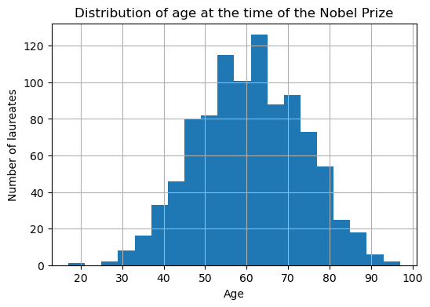

```python
plt.figure(figsize=(6, 4))
age_data["age_at_award"].hist(bins=20)
plt.title("Distribution of age at the time of the Nobel Prize")
plt.xlabel("Age")
plt.ylabel("Number of laureates")
plt.show()
```

Most laureates receive their prize somewhere between the late 30s and early 70s,  
with the bulk of the distribution roughly in the 50–60 range.

```python
# compare average age across categories
age_by_category = (
    age_data.groupby("category")["age_at_award"]
    .mean()
    .sort_values()
)
age_by_category
```

```
category
physics       57.522124
medicine      58.811404
chemistry     59.046632
peace         60.898148
literature    64.884298
economics     67.161290
Name: age_at_award, dtype: float64
```

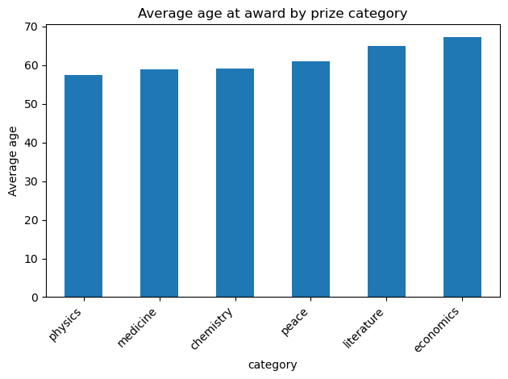

```python
age_by_category.plot(kind="bar")
plt.title("Average age at award by prize category")
plt.ylabel("Average age")
plt.xticks(rotation=45, ha="right")
plt.tight_layout()
plt.show()
```

Different prize categories have slightly different average ages.  
For example, some fields tend to recognize work a bit earlier,  
while others, such as lifetime contributions, may lead to prizes at a later age.  
The differences are not huge, but they are still interesting to see.

## Q8: Which birth cities show up most often?

I’m checking which birth cities appear most often in the dataset to see if Nobel laureates tend to come from a few major hubs.

```python
city_counts = (
    nobel_clean["bornCity"]
    .value_counts()
    .head(10)
)
city_counts
```

```
bornCity
New York NY        55
Paris              30
London             21
Vienna             14
Chicago IL         14
Berlin             11
Boston MA           9
Brooklyn NY         8
Budapest            8
Washington D.C.     8
Name: count, dtype: int64
```

It hints at a few major academic centers that have produced multiple Nobel laureates. New York shows up the most (55), followed by Paris (30) and London (21), which the top birth cities are mostly major global hubs. This is just a frequency count, and the ranking can be slightly affected by missing values or inconsistent city names.

## Overall

Looking back at the eight questions, a few patterns stand out clearly.

- Awards increase over time, with strong growth in the mid-to-late 20th century.
- A small number of birth countries/cities appear repeatedly.
- The gender distribution is heavily skewed.
- Age-at-award stays in a fairly consistent range, with modest category differences.

Overall, the results make the patterns behind the Nobel Prizes much easier to see: concentrated countries, a strong gender imbalance, steady growth over time, and a fairly consistent range of award ages.

## Limitations

Birth place is not the same as where the Nobel-winning work happened. Some records are missing dates/locations, and some place names may be historical.

## Useful Resources

Data source:

- Nobel Prize dataset（csv): http://api.nobelprize.org/v1/laureate.csv

Python / Pandas:

- Pandas user guide: https://pandas.pydata.org/docs/user_guide/index.html
- Pandas groupby: https://pandas.pydata.org/docs/user_guide/groupby.html

Plotting:

- Matplotlib pyplot: https://matplotlib.org/stable/tutorials/introductory/pyplot.html

Notebook publishing:

- GitHub Pages: https://github.com/Nmsl985211/DS220_project2_JunboZhao